# Lab 4

Tyler Kruzan & Cameron Stocker

10/23/2019

# Outline

We are using `dplyr & tidyr` to manipulate and clean a dataset with 2018 Iowa State Football statistics. This dataset includes stats collected from both sides of the ball, Offense & Defense for every game of the 2018 season as well as information regarding each player’s background. To get more information about the players we will have use joins in order to get the data from the offense and defense data sets available to be be used with the biography data set.

# Step 1: Cleaning

```r
offClean = offense %>%
  mutate(Name = as.factor(Name)) %>%
  mutate(Opponent_Opponent = as.factor(Opponent_Opponent))
defClean = defense %>%
  mutate(Name = as.factor(Name)) %>%
  mutate(Opponent_Opponent = as.factor(Opponent_Opponent))
bioClean = bio %>%
  mutate(Name = as.factor(Name))
defClean = mutate_at(defClean, names(defClean[,3:length(defClean)]), as.numeric)
offClean = mutate_at(offClean, names(offClean[,3:length(offClean)]), as.numeric)
bioClean = mutate_at(bioClean, "Weight", as.numeric)
bioClean = bioClean %>% separate("Height", sep = "-", into = c("Feet", "inches")) %>% mutate_at(c("Feet", "inches"), as.numeric) %>% mutate(Height = Feet*12 + inches) %>% select(-Feet,-inches)
str(defClean)
```

```
## Classes 'tbl_df', 'tbl' and 'data.frame':    446 obs. of  11 variables:
##  $ Name             : Factor w/ 42 levels "Akers, Landen",..: 7 7 7 7 7 7 7 7 7 7 ...
##  $ Opponent_Opponent: Factor w/ 13 levels "Akron","Baylor",..: 4 7 1 9 8 13 11 5 2 10 ...
##  $ Tackles_Solo     : num  3 6 7 6 3 5 3 7 2 9 ...
##  $ Tackles_ASST     : num  3 8 2 3 0 3 2 1 4 3 ...
##  $ Tackles_TFL      : num  0 1 1 0 1 1 0 0 0 0 ...
##  $ Tackles_Sack     : num  0 0 0 0 0 1 0 0 0 0 ...
##  $ Turnover_FF      : num  0 1 0 0 0 0 0 0 0 1 ...
##  $ Turnover_FR      : num  0 0 0 0 0 0 0 0 0 0 ...
##  $ Turnover_INT     : num  0 0 0 0 0 0 1 0 0 0 ...
##  $ Pass_QBH         : num  0 0 0 0 0 0 0 0 0 0 ...
##  $ Pass_PB          : num  0 0 3 0 0 0 0 0 0 0 ...
```

```r
str(offClean)
```

```
## Classes 'tbl_df', 'tbl' and 'data.frame':    168 obs. of  12 variables:
##  $ Name             : Factor w/ 15 levels "Akers, Landen",..: 6 6 6 6 6 6 6 6 6 6 ...
##  $ Opponent_Opponent: Factor w/ 13 levels "Akron","Baylor",..: 4 7 1 9 8 13 11 5 2 10 ...
##  $ Receiving_REC    : num  1 9 6 3 6 1 1 4 4 0 ...
##  $ Receiving_YDS    : num  31 66 39 23 37 32 4 31 39 0 ...
##  $ Receiving_TD     : num  0 0 0 0 1 1 0 0 1 0 ...
##  $ Rushing_ATT      : num  NA NA NA NA NA NA NA NA NA NA ...
##  $ Rushing_YDS      : num  NA NA NA NA NA NA NA NA NA NA ...
##  $ Rushing_TD       : num  NA NA NA NA NA NA NA NA NA NA ...
##  $ Passing_CMP-ATT  : num  NA NA NA NA NA NA NA NA NA NA ...
##  $ Passing_YDS      : num  NA NA NA NA NA NA NA NA NA NA ...
##  $ Passing_TD       : num  NA NA NA NA NA NA NA NA NA NA ...
##  $ Passing_INT      : num  NA NA NA NA NA NA NA NA NA NA ...
```

```r
str(bioClean)
```

```
## Classes 'tbl_df', 'tbl' and 'data.frame':    123 obs. of  7 variables:
##  $ Name      : Factor w/ 123 levels "Akers, Landen",..: 1 2 3 4 5 6 7 8 9 10 ...
##  $ Position  : chr  "Wide Receiver" "Tight End" "Offensive Line" "Tight End" ...
##  $ Weight    : num  192 240 290 250 191 205 192 224 251 284 ...
##  $ Class     : chr  "Redshirt Sophomore" "Redshirt Sophomore" "Redshirt Freshman" "Redshirt Senior" ...
##  $ Hometown  : chr  "Cedar Rapids, Iowa" "Nixa, Mo." "Cedar Rapids, Iowa" "League City, Texas" ...
##  $ Highschool: chr  "Washington" "Nixa" "Washington" "Clear Falls" ...
##  $ Height    : num  72 79 74 76 72 71 72 75 74 74 ...
```

# Step 2: Tidying the Clean Defense Data

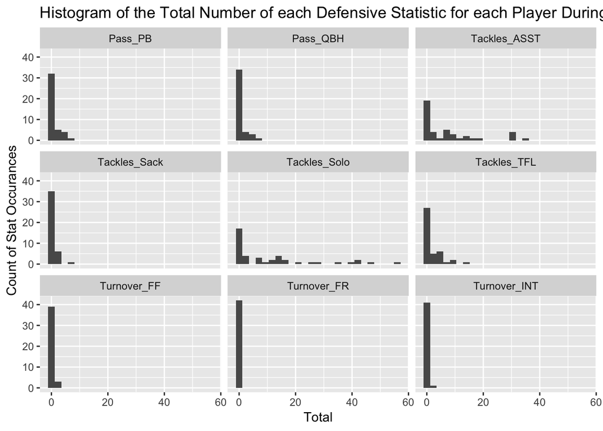

```r
defGather = defClean %>%
  gather(key = Statistic, value = Total, 3:11)
###Group the data to look at each player's season totals to get a better idea of which statistics are more rare
defenseGroup =  defGather %>% group_by(Name, Statistic) %>% summarize(Total = sum(Total))
defenseGroup %>%
  ggplot(aes(Total)) + geom_histogram(bins = 25) + facet_wrap(~Statistic) + labs(title = "Histogram of the Total Number of each Defensive Statistic for each Player During the Season", y = "Count of Stat Occurances")
```

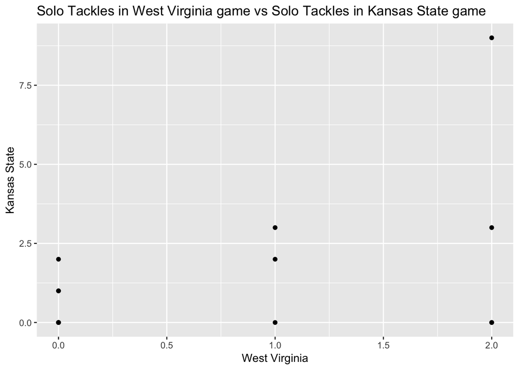

```r
defGather %>%
  filter(Statistic == "Tackles_Solo" & Opponent_Opponent == c("West Virginia","Kansas State")) %>%
  spread(key = Opponent_Opponent, value = Total) %>%
  ggplot(aes(x = `West Virginia`, y = `Kansas State`)) + geom_point() + labs(title = "Solo Tackles in West Virginia game vs Solo Tackles in Kansas State game", x = "West Virginia", y = "Kansas State")
```

Above is a plot of solo tackles in the West Virginia vs the solo tackles in the Kansas State game. It appears that Iowa State had better defense against Kansas State as there are a higher number of solo tackles along the y-axis.

```r
bioClean = bioClean %>% separate("Hometown", sep = ", ", into = c("City", "State"))
bioClean %>% select(City, State) %>% head()
```

```
## # A tibble: 6 x 2
##   City         State
##   <chr>        <chr>
## 1 Cedar Rapids Iowa
## 2 Nixa         Mo.
## 3 Cedar Rapids Iowa
## 4 League City  Texas
## 5 Naperville   Ill.
## 6 Walnut       Calif.
```

Above are the first few rows from the City and State columns.

```r
bioClean %>% group_by(State) %>% summarize(n=n()) %>% print()
```

```
## # A tibble: 25 x 2
##    State         n
##    <chr>     <int>
##  1 Ariz.         3
##  2 Ark.          2
##  3 Australia     2
##  4 Calif.        8
##  5 D.C.          1
##  6 Fla.          8
##  7 Ga.           2
##  8 Ill.          5
##  9 Iowa         44
## 10 Kan.          3
## # … with 15 more rows
```

Above is a list of the number of players from each state.

# Step 3: Joining Data Frames

From the scatterplot below, it does not appear that weight has a relationship with the amount of receiving yards from a player.

```r
offBios = inner_join(bioClean, offClean, by=c("Name"))
```

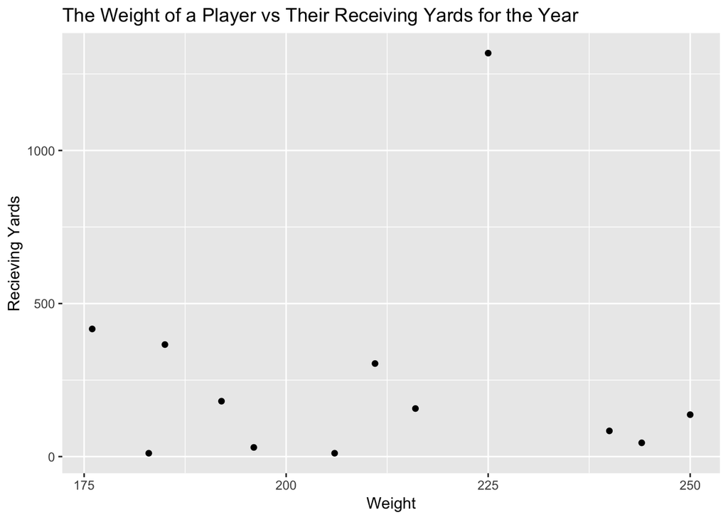

```r
offBios %>% group_by(Weight) %>% summarize(Receiving_YDS = sum(Receiving_YDS)) %>% ggplot(aes(Weight, Receiving_YDS)) + geom_point() + labs(title = "The Weight of a Player vs Their Receiving Yards for the Year", y = "Recieving Yards")
```

Question: Of the non-lineman positions, which positions have the highest weights on average?

Answer: After examining the plot below, it looks like the Tight End and Linebacker positions have the highest mean weight, with cornerbacks having the lowest.

```r
defBios = inner_join(bioClean, defense, by=c("Name"))
```

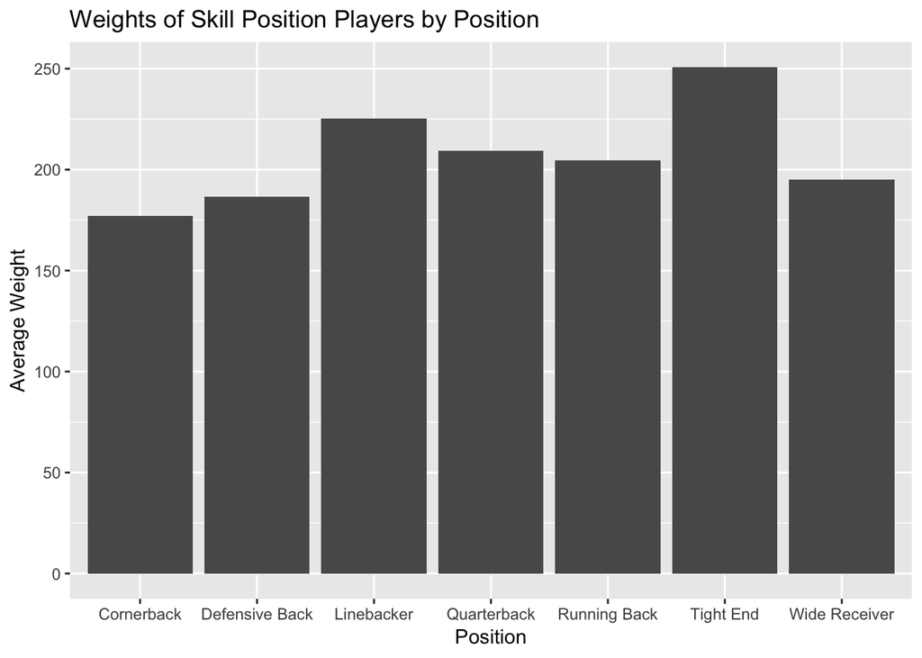

```r
offTrim = select(offBios, Name, Position, Weight)
defTrim = select(defBios, Name, Position, Weight)
allTrim = rbind(offTrim, defTrim)
allTrim = filter(allTrim)
allTrim %>% filter(Position == c("Wide Receiver", "Tight End", "Quarterback", "Running Back", "Defensive Back", "Linebacker", "Cornerback")) %>% group_by(Position) %>% summarize(meanWeight = mean(Weight)) %>% ggplot(aes(x = Position, y = meanWeight)) + geom_bar(stat = "identity") + labs(title = "Weights of Skill Position Players by Position", y = "Average Weight")
```